# Exploration of FIFA World Cup Data

## Investigation Overview

For the presentation, I focused on three things: countries, continents and attendance. I started by introducing countries with highest appearance, then a set of plots which shows relationship between countries and continents. Lastly, I introduced plots with 'attendance' as area of focus

## Dataset Overview

The datasets. This project features three datasets:  
The first dataset contains basic match information such as home team name, stadium, city, referee name and so on. The second dataset contains player information such as player name, shirt number, position etc. The last dataset contains information about the tournament such as the winners, runner-ups, qualified team, goals scored etc.

## How many countries have participated in the FIFA World Cup?

A total of 83 countries have participated in the FIFA World Cup with Argentina having the highest number of appearance, 16.

```
83
```

```
Argentina    16
Brazil       15
Mexico       15
Italy        14
France       14
Name: Away Team Name, dtype: int64
```

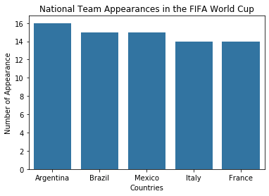

## How many countries from each continent have participated in the FIFA World Cup?

Countries from Europe have the highest number of appearances in the FIFA World Cup. 'Appearance' here does not denote number of matches played but rather participation per year.

```
Europe           210
South America     73
Asia              44
Africa            39
North America     39
Name: Away Team Continent, dtype: int64
```

[figure not shown]

## How does the attendance vary over the past tournaments?

A higher number of people watched the first world cup compared to the next two subsequent tournaments. Also, there is a significant drop around 1998 and 2002.

```
Year
1930     590549.0
1934     363000.0
1938     375700.0
1950    1045246.0
1954     768607.0
Name: Attendance, dtype: float64
```

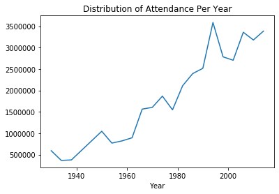

## Which country has hosted the World Cup the most?

Each of France, Brazil, Germany, Mexico and Italy have hosted the World Cup twice while Korea and Japan both jointly hosted the tournament once. The rest of the countries hosted once

```
Mexico     2
France     2
Germany    2
Name: Host Country, dtype: int64
```

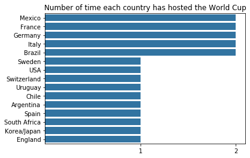

## Which country has the number of World Cup trophy?

South America country Brazil has the highest number of World Cup trophy; 5 in their cabinet!

```
Brazil        5
Italy         4
Germany FR    3
Uruguay       2
Argentina     2
Name: Winner, dtype: int64
```

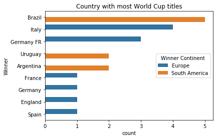

## What effect does a home country's continent have on the attendance of spectators?

Countries in South America seem to have better spectator turn out

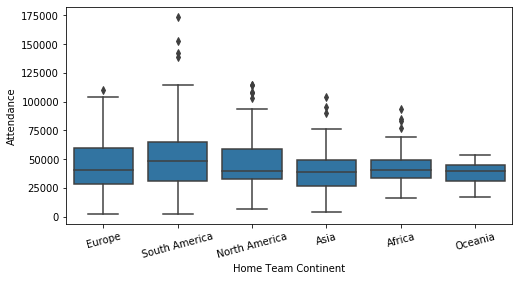

## How does the attendance vary over the past finals?

```
Year
1930     68346
1934     55000
1938     45000
1950    173850
1954     62500
Name: Attendance, dtype: int64
```

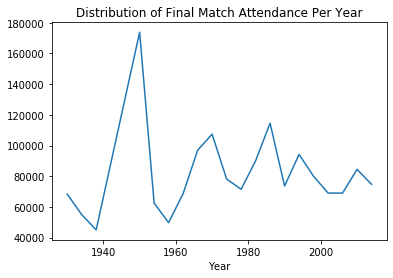